# analysis

2024-01-11

```r
library(tidyverse)
```

##Create a table with the total number of participants before exclusions.

```r
#load the processed_data dataset

getwd()
```

```
## [1] "/Users/tobiasboschung/Documents/GitHub/dpm-assignments/personality and race-IAT study/code"
```

```r
data_processed <- read_csv("../data/processed/data_processed.csv")
library(dplyr)

# Assuming 'participant' is the column with unique participant identifiers
n_participants_before_exclusion <- data_processed %>%
                                   summarise(count = n_distinct(participant))

print(n_participants_before_exclusion)
```

```
## # A tibble: 1 × 1
##   count
##   <int>
## 1  1933
```

## Exclude participants using the master exclusion variable.

```r
library(dplyr)

# Filter data to include only participants marked as 'include'
data_processed_after_exclusions <- data_processed %>%
                         filter(exclude_participant == "include")

# You can then work with this new dataset 'data_processed_after_exclusions'
```

## Create a table with the total number of participants after exclusions.

```r
total_participants_after_exclusions <- data_processed_after_exclusions %>%
                                       summarise(Total_Participants = n())

# Print the table with the total number of participants
print(total_participants_after_exclusions)
```

```
## # A tibble: 1 × 1
##   Total_Participants
##                <int>
## 1                152
```

```r
library(kableExtra)
library(janitor)
data_processed_after_exclusions |>
  mutate(age = as.numeric(age)) |>
  summarise(Mean = mean(age, na.rm = TRUE),
            SD = sd(age, na.rm = TRUE)) |>
  mutate_all(.funs = janitor::round_half_up, digits = 1) |>
  kable() |>
  add_header_above(header = c("Age" = 2)) |>
  kable_classic(full_width = FALSE)
```

| Age Mean | Age SD |
| --- | --- |
| 30.3 | 11 |

```r
data_processed_after_exclusions |>
  group_by(sex) |>
  summarise(n = n()) |>
  mutate(Percent = paste0(round_half_up((n / sum(n)) * 100, 1), "%")) |>
  mutate(sex = stringr::str_to_sentence(sex)) |>
  kable() |>
  kable_classic(full_width = FALSE)
```

| sex | n | Percent |
| --- | --- | --- |
| F | 90 | 59.2% |
| M | 62 | 40.8% |

## Calculate Cronbach’s alpha for each of the BFI subscales.

```r
library(psych)
# Define the columns for each trait
traits <- list(
  Agreeableness = c("bfi_a1", "bfi_a2", "bfi_a3", "bfi_a4", "bfi_a5", "bfi_a6", "bfi_a7", "bfi_a8", "bfi_a9"),
  Conscientiousness = c("bfi_c1", "bfi_c2", "bfi_c3", "bfi_c4", "bfi_c5", "bfi_c6", "bfi_c7", "bfi_c8", "bfi_c9"),
  Extraversion = c("bfi_e1", "bfi_e2", "bfi_e3", "bfi_e4", "bfi_e5", "bfi_e6", "bfi_e7", "bfi_e8"),
  Neuroticism = c("bfi_n1", "bfi_n2", "bfi_n3", "bfi_n4", "bfi_n5", "bfi_n6", "bfi_n7", "bfi_n8"),
  Openness = c("bfi_o1", "bfi_o2", "bfi_o3", "bfi_o4", "bfi_o5", "bfi_o6", "bfi_o7", "bfi_o8", "bfi_o9", "bfi_o10")
)

# Loop through each trait to calculate alpha
for (trait in names(traits)) {
  cat(trait, ": raw_alpha ", alpha(subset(data_processed_after_exclusions, select = traits[[trait]]), check.keys = TRUE)$total$raw_alpha, "is rated as good rel.\n")
}
```

```
## Agreeableness : raw_alpha  0.7904585 is rated as good rel.
## Conscientiousness : raw_alpha  0.8169249 is rated as good rel.
## Extraversion : raw_alpha  0.8156385 is rated as good rel.
## Neuroticism : raw_alpha  0.8016962 is rated as good rel.
## Openness : raw_alpha  0.7750597 is rated as good rel.
```

## - Create series of histograms of the distribution of scores on each of the BFI subscales

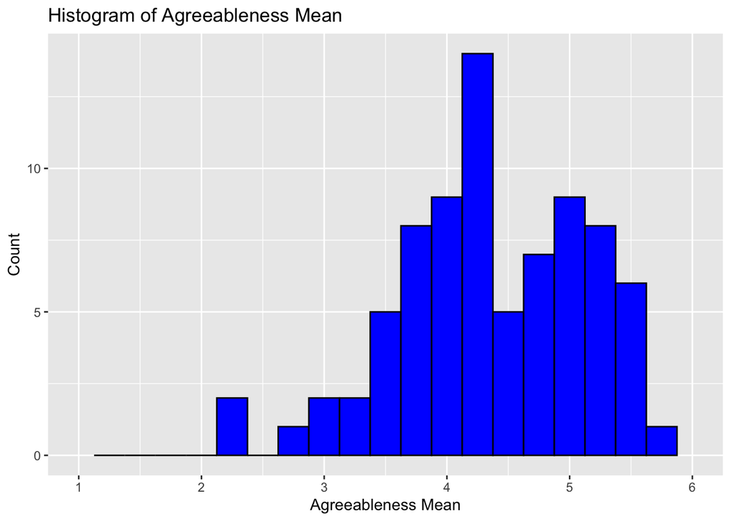

```r
#Histograms for all the BFI- Subscales
library(ggplot2)

ggplot(data_processed_after_exclusions, aes(x=agreeableness_mean)) +
  geom_histogram(binwidth = 0.25, fill="blue", color="black") +
  labs(title="Histogram of Agreeableness Mean", x="Agreeableness Mean", y="Count") +
  scale_x_continuous(limits = c(1, 6), breaks=1:6)
```

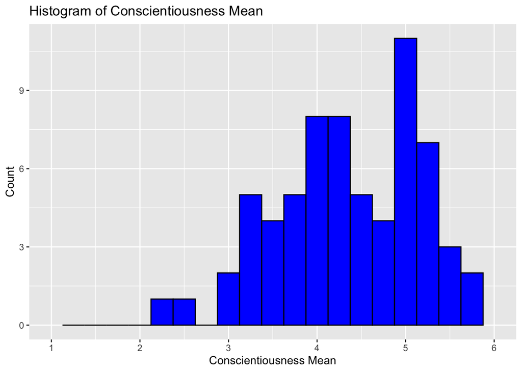

```r
# Histogram for conscientiousness_mean
ggplot(data_processed_after_exclusions, aes(x=conscientiousness_mean)) +
  geom_histogram(binwidth = 0.25, fill="blue", color="black") +
  labs(title="Histogram of Conscientiousness Mean", x="Conscientiousness Mean", y="Count") +
  scale_x_continuous(limits = c(1, 6), breaks=1:6)
```

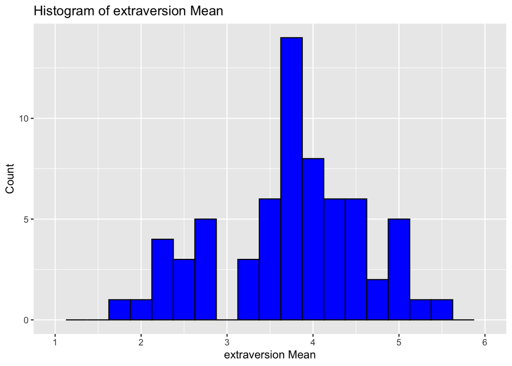

```r
# Histogram for extraversion
ggplot(data_processed_after_exclusions, aes(x=extraversion_mean)) +
  geom_histogram(binwidth = 0.25, fill="blue", color="black") +
  labs(title="Histogram of extraversion Mean", x="extraversion Mean", y="Count") +
  scale_x_continuous(limits = c(1, 6), breaks=1:6)
```

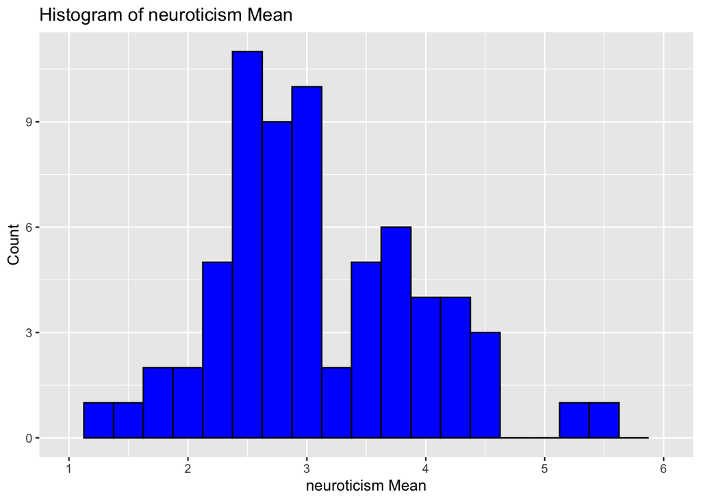

```r
# Histogram for neuroticism
ggplot(data_processed_after_exclusions, aes(x=neuroticism_mean)) +
  geom_histogram(binwidth = 0.25, fill="blue", color="black") +
  labs(title="Histogram of neuroticism Mean", x="neuroticism Mean", y="Count") +
  scale_x_continuous(limits = c(1, 6), breaks=1:6)
```

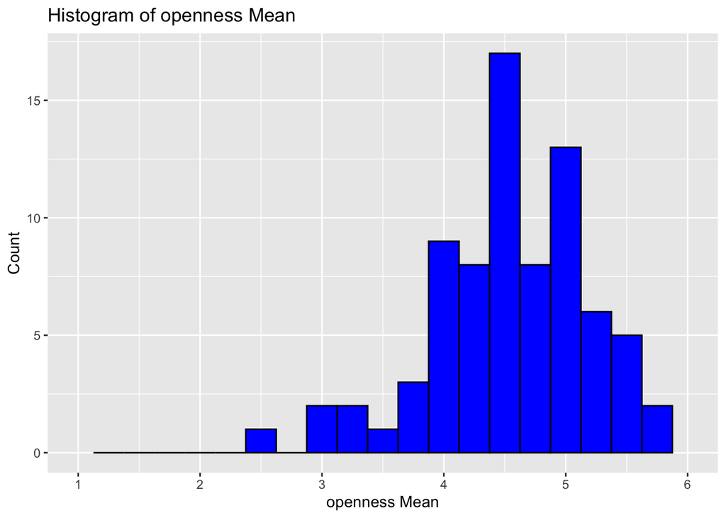

```r
# Histogram for openness
ggplot(data_processed_after_exclusions, aes(x=openness_mean)) +
  geom_histogram(binwidth = 0.25, fill="blue", color="black") +
  labs(title="Histogram of openness Mean", x="openness Mean", y="Count") +
  scale_x_continuous(limits = c(1, 6), breaks=1:6)
```

## - Create series of histograms of the distribution of scores for the IAT.

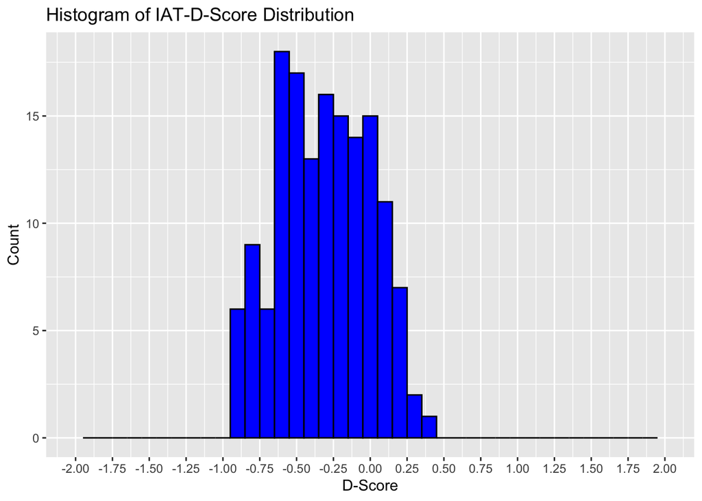

```r
library(ggplot2)

ggplot(data_processed_after_exclusions, aes(x=D)) +
  geom_histogram(binwidth = 0.1, fill="blue", color="black", na.rm = TRUE) +
  labs(title="Histogram of IAT-D-Score Distribution", x="D-Score", y="Count") +
  scale_x_continuous(
    limits = c(-2, 2),
    breaks = seq(-2, 2, by = 0.25))
```

Create a table with a correlation matrix of the Pearson’s r correlations between the IAT and the BFI subscales rounded to two decimal places.

```r
# Load the necessary library
library(Hmisc)
# Subset the dataframe to include only the relevant variables
data_correlation <- data_processed_after_exclusions[c("D", "agreeableness_mean", "conscientiousness_mean", "extraversion_mean", "neuroticism_mean", "openness_mean")]

# Use the cor function with the method "pearson" and use the use="pairwise.complete.obs"
# to ensure that only pairwise complete observations are used for each correlation
cor_matrix <- cor(data_correlation, method = "pearson", use = "pairwise.complete.obs")

# Round the correlation matrix to two decimal places
cor_matrix_rounded <- round(cor_matrix, 2)

# Print the correlation matrix
print(cor_matrix_rounded)
```

```
##                            D agreeableness_mean conscientiousness_mean
## D                       1.00               0.02                   0.01
## agreeableness_mean      0.02               1.00                     NA
## conscientiousness_mean  0.01                 NA                   1.00
## extraversion_mean       0.01                 NA                   0.11
## neuroticism_mean        0.12                 NA                  -0.35
## openness_mean          -0.07               0.16                     NA
##                        extraversion_mean neuroticism_mean openness_mean
## D                                   0.01             0.12         -0.07
## agreeableness_mean                    NA               NA          0.16
## conscientiousness_mean              0.11            -0.35            NA
## extraversion_mean                   1.00            -0.10            NA
## neuroticism_mean                   -0.10             1.00            NA
## openness_mean                         NA               NA          1.00
```

## Run a t-test to test the hypothesis that men and women differ on their scores on the IAT. Report and interpret the results using {report}.

```r
# Install and load the report package
if (!requireNamespace("report", quietly = TRUE)) {
  install.packages("report")
}
library(report)

# Run the t-test
t_test_result <- t.test(D ~ sex, data = data_processed_after_exclusions)

# Generate a report
report_result <- report(t_test_result)
# Print the report
print(report_result)
```

```
## Effect sizes were labelled following Cohen's (1988) recommendations.
##
## The Welch Two Sample t-test testing the difference of D by sex (mean in group f
## = -0.29, mean in group m = -0.36) suggests that the effect is positive,
## statistically not significant, and small (difference = 0.07, 95% CI [-0.04,
## 0.17], t(119.05) = 1.25, p = 0.214; Cohen's d = 0.23, 95% CI [-0.13, 0.59])
```

## - Run a series of regressions to test the hypotheses that each BFI subscale predicts IAT scores. Run separate regressions for each subscale rather than a multiple regression. Report and interpret the results using {report}.

```r
# List of BFI subscales
bfi_subscales <- c("agreeableness_mean", "conscientiousness_mean", "extraversion_mean", "neuroticism_mean", "openness_mean")

# Loop through each BFI subscale and run a regression
for (subscale in bfi_subscales) {
  regression_formula <- as.formula(paste("D ~", subscale))
  regression_result <- lm(regression_formula, data = data_processed_after_exclusions)

  # Report the results
  report_result <- report(regression_result)
  print(paste("Regression result for", subscale, ":"))
  print(report_result)
}
```

```
## [1] "Regression result for agreeableness_mean :"
## We fitted a linear model (estimated using OLS) to predict D with
## agreeableness_mean (formula: D ~ agreeableness_mean). The model explains a
## statistically not significant and very weak proportion of variance (R2 =
## 2.85e-04, F(1, 78) = 0.02, p = 0.882, adj. R2 = -0.01). The model's intercept,
## corresponding to agreeableness_mean = 0, is at -0.33 (95% CI [-0.74, 0.09],
## t(78) = -1.58, p = 0.119). Within this model:
##
##   - The effect of agreeableness mean is statistically non-significant and
## positive (beta = 6.95e-03, 95% CI [-0.09, 0.10], t(78) = 0.15, p = 0.882; Std.
## beta = 0.02, 95% CI [-0.21, 0.24])
##
## Standardized parameters were obtained by fitting the model on a standardized
## version of the dataset. 95% Confidence Intervals (CIs) and p-values were
## computed using a Wald t-distribution approximation.
## [1] "Regression result for conscientiousness_mean :"
## We fitted a linear model (estimated using OLS) to predict D with
## conscientiousness_mean (formula: D ~ conscientiousness_mean). The model
## explains a statistically not significant and very weak proportion of variance
## (R2 = 1.50e-04, F(1, 64) = 9.60e-03, p = 0.922, adj. R2 = -0.02). The model's
## intercept, corresponding to conscientiousness_mean = 0, is at -0.36 (95% CI
## [-0.77, 0.05], t(64) = -1.75, p = 0.085). Within this model:
##
##   - The effect of conscientiousness mean is statistically non-significant and
## positive (beta = 4.56e-03, 95% CI [-0.09, 0.10], t(64) = 0.10, p = 0.922; Std.
## beta = 0.01, 95% CI [-0.24, 0.26])
##
## Standardized parameters were obtained by fitting the model on a standardized
## version of the dataset. 95% Confidence Intervals (CIs) and p-values were
## computed using a Wald t-distribution approximation.
## [1] "Regression result for extraversion_mean :"
## We fitted a linear model (estimated using OLS) to predict D with
## extraversion_mean (formula: D ~ extraversion_mean). The model explains a
## statistically not significant and very weak proportion of variance (R2 =
## 1.11e-04, F(1, 64) = 7.08e-03, p = 0.933, adj. R2 = -0.02). The model's
## intercept, corresponding to extraversion_mean = 0, is at -0.35 (95% CI [-0.69,
## -8.77e-03], t(64) = -2.05, p = 0.045). Within this model:
##
##   - The effect of extraversion mean is statistically non-significant and positive
## (beta = 3.67e-03, 95% CI [-0.08, 0.09], t(64) = 0.08, p = 0.933; Std. beta =
```

[output cut: 20 more lines]

```
## [1] "Regression result for openness_mean :"
## We fitted a linear model (estimated using OLS) to predict D with openness_mean
## (formula: D ~ openness_mean). The model explains a statistically not
## significant and very weak proportion of variance (R2 = 4.74e-03, F(1, 78) =
## 0.37, p = 0.544, adj. R2 = -8.02e-03). The model's intercept, corresponding to
## openness_mean = 0, is at -0.15 (95% CI [-0.64, 0.33], t(78) = -0.62, p =
## 0.536). Within this model:
##
##   - The effect of openness mean is statistically non-significant and negative
## (beta = -0.03, 95% CI [-0.14, 0.07], t(78) = -0.61, p = 0.544; Std. beta =
## -0.07, 95% CI [-0.29, 0.16])
##
## Standardized parameters were obtained by fitting the model on a standardized
## version of the dataset. 95% Confidence Intervals (CIs) and p-values were
## computed using a Wald t-distribution approximation.
```

## - Create series of scatter plots of how BFI subscale scores predict IAT scores. Add regression lines. These plots therefore illustrate the same results as the regressions above. Make the plots presentable and publication quality- you may decide the details of this with one exception: Extreme scores on the IAT (defined as participants whose scores in the top and bottom 10% of IAT scores) should use a triangular shape rather than a dot. A single combined plot should be created, containing 5 component plots, with the personality facet being examined in each clearly labelled. This plot should be printed in the html file but also saved to disk as both png/pdf.Note: The Png and PDF version of the plots look way better than what is printed in here, so check those.

[figure not shown]

```r
library(ggplot2)
library(dplyr)
library(gridExtra)
# Identify the top and bottom 10% of IAT scores
threshold_high <- quantile(data_processed_after_exclusions$D, 0.9, na.rm = TRUE)
threshold_low <- quantile(data_processed_after_exclusions$D, 0.1, na.rm = TRUE)

# Create a new column for shape
data_processed_after_exclusions$shape <- ifelse(data_processed_after_exclusions$D >= threshold_high | data_processed_after_exclusions$D <= threshold_low, "triangle", "circle")

# List of BFI subscales
bfi_subscales <- c("agreeableness_mean", "conscientiousness_mean", "extraversion_mean", "neuroticism_mean", "openness_mean")

# Create a list to store plots
plots_list <- list()

# Generate plots for each subscale
for (subscale in bfi_subscales) {
  p <- ggplot(data_processed_after_exclusions, aes_string(x=subscale, y="D", shape="shape")) +
    geom_jitter(width = 0.1, height = 0, size = 2.5, alpha = 0.6) +
    geom_smooth(method="lm", se=FALSE, aes(group = 1)) +
    labs(
      title=paste("IAT scores vs", subscale),
      x=subscale,
      y="IAT Score",
      caption = "Note: Points have been jittered horizontally for visualization purposes, extreme values are represented by triangles."
    ) +
    scale_shape_manual(values=c(circle=16, triangle=17)) +
    theme(legend.position = "none")

  plots_list[[subscale]] <- p
}
# Combine the plots into a single plot
combined_plot <- do.call(grid.arrange, c(plots_list, ncol=1))
```

```r
# Save the plot
ggsave("bfi_iat_relationship.png", combined_plot, width = 10, height = 30)
ggsave("bfi_iat_relationship.pdf", combined_plot, width = 10, height = 30)

# Print the plot for the HTML file
print(combined_plot)
```

```r
#Note: The Png and PDF version of the plots look way better than what is printed in here, so check those.
```

## Combine these scatter plots into one ggplot object using {patchwork} and print the combined plot in your .Rmd and .html. Save the combined plot to disk as a .pdf and .png in the “communications” folder. Note: The Png and PDF version of the plots look way better than what is printed in here, so check those.

[figure not shown]

```r
# Install and load the patchwork package if you haven't already
if (!requireNamespace("patchwork", quietly = TRUE)) {
  install.packages("patchwork")
}
library(patchwork)

# Identify the top and bottom 10% of IAT scores
threshold_high <- quantile(data_processed_after_exclusions$D, 0.9, na.rm = TRUE)
threshold_low <- quantile(data_processed_after_exclusions$D, 0.1, na.rm = TRUE)

# Create a new column for shape
data_processed_after_exclusions$shape <- ifelse(data_processed_after_exclusions$D >= threshold_high | data_processed_after_exclusions$D <= threshold_low, "triangle", "circle")

# List of BFI subscales
bfi_subscales <- c("agreeableness_mean", "conscientiousness_mean", "extraversion_mean", "neuroticism_mean", "openness_mean")

# Create a list to store plots
plots_list <- list()

# Generate plots for each subscale
for (subscale in bfi_subscales) {
  p <- ggplot(data_processed_after_exclusions, aes_string(x=subscale, y="D", shape="shape")) +
    geom_jitter(width = 0.1, height = 0, size = 2.5, alpha = 0.6) +
    geom_smooth(method="lm", se=FALSE, aes(group = 1)) +
    labs(
      title=paste("IAT scores vs", subscale),
      x=subscale,
      y="IAT Score",
      caption = "Note: Points have been jittered horizontally for visualization purposes, extreme values are represented by triangles."
    ) +
    scale_shape_manual(values=c(circle=16, triangle=17)) +
    theme(legend.position = "none")

  plots_list[[subscale]] <- p
}


# Combine the plots into a single plot using patchwork
combined_plot <- patchwork::wrap_plots(plots_list, ncol = 1)

# Print the combined plot for the R Markdown (.Rmd) and HTML file
print(combined_plot)
```

```r
# Save the combined plot to the "communications" folder as .pdf and .png
ggsave("../communications/bfi_iat_relationship.png", combined_plot, width = 10, height = 30)
ggsave("../communications/bfi_iat_relationship.pdf", combined_plot, width = 10, height = 30)
#Note: The Png and PDF version of the plots look way better than what is printed in here, so check those.
```